# Cleaning Tick Data

Zoe Zilz

9/24/2019

We need to clean up the data so that it works with the “survival” package First let’s install the necessary packages:

```r
#install.packages("survival")
#install.packages("KMsurv")
#install.packages("survminer")
#install.packages("tidyverse")
#install.packages("ggfortify")
#install.packages("car")
# this package should include some example data
#install.packages("lubridate")
#install.packages("coxme")
#install.packages("splitstackshape")


library(survival)
library(KMsurv)
library(survminer)
library(tidyverse)
library(ggplot2)
library(readr)
library(coxme)
#library(ggfortify)
#library(ggthemes)
#library(extrafont)
#library(Design)
#library(rms)
library(car)
#library(scales) # For the percent_format() function
#loadfonts(device = "pdf")
library(lubridate)
library(splitstackshape)
```

Importing data (when re-doing this, can skip ahead to the next part and just import the new csv)

-in excel, I manually added in rows for the survivors depending on how many were alive at the end of the thing (10/21/18) -also added a column of death_tf -this all probably could have been done in R but i didnt want to write the code to conditionally expand (uncount) only if date = 10/21/18 (plus other factors had to be true)… maybe figure this out later -at this point easier to just do manually -also added a column with date_start (7/28/18) even though this could have easily been coded

## 2018

### Cleaning 2018 Data

```r
# importing the new set
tick18_complete <- read_csv("tick18_complete.csv")
```

```r
#clean it up and remove useless shit
tick18_clean <- tick18_complete %>%
  select(SITE, BLOCK, PLOT, SPECIES, date_start, date_alive, death_t_f) %>%
  rename(climate = SITE, exclosure = PLOT, species = SPECIES, block = BLOCK)


# need lubridate to calculate interval between start and death date

tick18_clean$date_start <- as.Date(tick18_clean$date_start)
tick18_clean$date_alive <- as.Date(tick18_clean$date_alive)

tick18_final <- tick18_clean %>%
  mutate(days_elpsd = as.double(difftime(ymd(date_alive), ymd(date_start), units = "days"))) %>%
  mutate(excl_ranked = case_when(
    exclosure == "W" ~ 2, # partial
    exclosure == "WC" ~ 1, # open
    exclosure == "O" ~ 3 # total
  ))

### NOTE: for some reason that I can't understand, both exclosure and excl_ranked are invisible unless their dataframe is before them e.g. tick18_final$exclosure

tick18_final$exclosure <- as.factor(tick18_final$exclosure) # also not sure why this is necessary, but it is

head(tick18_final)
```

```
## # A tibble: 6 x 9
##   climate block exclosure species date_start date_alive death_t_f days_elpsd
##   <chr>   <dbl> <fct>     <chr>   <date>     <date>         <dbl>      <dbl>
## 1 ARID        1 O         DEVA    2018-07-28 2018-08-05         1          8
## 2 ARID        1 O         DEVA    2018-07-28 2018-08-05         1          8
## 3 ARID        1 O         DEVA    2018-07-28 2018-08-05         1          8
## 4 ARID        1 O         DEVA    2018-07-28 2018-08-05         1          8
## 5 ARID        1 O         DEVA    2018-07-28 2018-08-05         1          8
## 6 ARID        1 O         DEVA    2018-07-28 2018-08-05         1          8
## # ... with 1 more variable: excl_ranked <dbl>
```

Data Wrangling (2018)

*The following is redundant and has been solved above, but retaining it for lesson learning purposes*

### Data Analysis 2018

We have survival data and want to understand the roles of - tick species: Dermacentor vs. Ixodes - herbivore density: Partial exclosure (wild only), Total exclosure (no ungulates), Open (livestock and wild) - Climate: Arid, Mesic, Intermediate

## added for MS (9 Dec 2020)

microclimate data (humidity and temperature) as predictors in a second set of models instead of categorical herbivore treatment and aridity.

…in larval tick survival

We are going to run a Cox Proportional Hazards model because that is appropriate for assessing the impacts of multiple variables on survival time. The Cox Proportional Hazards model is a type of non-parametric? semi-parametric (linear predictors) regression. We need to run a MIXED EFFECTS Cox PH because of the need for a random block effect.

```r
#create the survival object
tick18_surv<- (Surv(tick18_final$days_elpsd, tick18_final$death_t_f, type ="right"))

# create COX PH model with plot (exclosure) and site (climate) and the interaction, plus block as a random effect
#tick18surv_model<-coxph(tick18_surv~ species * climate * exclosure * (1|block), data = tick18_final)
## the above base model does not work because cox PH doesn't allow for mixed (random) effects
### however, coxme (cox mixed effects) does! (code from: https://stats.idre.ucla.edu/r/dae/mixed-effects-cox-regression/)
tick18surv_model<-coxme(tick18_surv~ species * climate * exclosure + (1|block), data = tick18_final)
tick18surv_model
```

```
## Cox mixed-effects model fit by maximum likelihood
##   Data: tick18_final
##   events, n = 6201, 6479
##   Iterations= 11 68
##                     NULL Integrated    Fitted
## Log-likelihood -49097.43  -48167.46 -48164.89
##
##                     Chisq    df p     AIC     BIC
## Integrated loglik 1859.94 18.00 0 1823.94 1702.75
##  Penalized loglik 1865.07 18.65 0 1827.78 1702.23
##
## Model:  tick18_surv ~ species * climate * exclosure + (1 | block)
## Fixed coefficients
##                                               coef exp(coef)   se(coef)      z
## speciesIXPA                            0.544948690 1.7245199 0.07478266   7.29
## climateINTERM                         -0.656928028 0.5184415 0.07556612  -8.69
## climateMESIC                          -0.952088089 0.3859343 0.07770209 -12.25
## exclosureW                            -0.084655391 0.9188289 0.07465084  -1.13
## exclosureWC                            0.727993392 2.0709209 0.07505641   9.70
## speciesIXPA:climateINTERM             -0.300432026 0.7404982 0.10619425  -2.83
## speciesIXPA:climateMESIC              -0.551159689 0.5762811 0.10879838  -5.07
## speciesIXPA:exclosureW                 0.093741747 1.0982761 0.10549147   0.89
## speciesIXPA:exclosureWC               -0.240972429 0.7858633 0.10548995  -2.28
## climateINTERM:exclosureW               0.286910999 1.3323056 0.10646562   2.69
## climateMESIC:exclosureW                0.166547551 1.1812197 0.10846425   1.54
## climateINTERM:exclosureWC             -0.117967348 0.8887251 0.10616395  -1.11
## climateMESIC:exclosureWC              -0.667777577 0.5128471 0.10920526  -6.11
## speciesIXPA:climateINTERM:exclosureW   0.080497425 1.0838261 0.14999817   0.54
## speciesIXPA:climateMESIC:exclosureW   -0.005297918 0.9947161 0.15324864  -0.03
## speciesIXPA:climateINTERM:exclosureWC  0.282376813 1.3262784 0.14974940   1.89
## speciesIXPA:climateMESIC:exclosureWC   0.124113639 1.1321445 0.15429175   0.80
##                                             p
## speciesIXPA                           3.2e-13
## climateINTERM                         0.0e+00
## climateMESIC                          0.0e+00
## exclosureW                            2.6e-01
## exclosureWC                           0.0e+00
## speciesIXPA:climateINTERM             4.7e-03
## speciesIXPA:climateMESIC              4.1e-07
## speciesIXPA:exclosureW                3.7e-01
## speciesIXPA:exclosureWC               2.2e-02
## climateINTERM:exclosureW              7.0e-03
## climateMESIC:exclosureW               1.2e-01
## climateINTERM:exclosureWC             2.7e-01
## climateMESIC:exclosureWC              9.7e-10
## speciesIXPA:climateINTERM:exclosureW  5.9e-01
## speciesIXPA:climateMESIC:exclosureW   9.7e-01
## speciesIXPA:climateINTERM:exclosureWC 5.9e-02
## speciesIXPA:climateMESIC:exclosureWC  4.2e-01
##
## Random effects
##  Group Variable  Std Dev     Variance
##  block Intercept 0.047781198 0.002283043
```

```r
Anova(tick18surv_model)
```

```
## Analysis of Deviance Table (Type II tests)
##
## Response: tick18_surv
##                           Df     Chisq Pr(>Chisq)
## species                    1  115.4373  < 2.2e-16 ***
## climate                    2 1515.8285  < 2.2e-16 ***
## exclosure                  2  189.2182  < 2.2e-16 ***
## species:climate            2   67.1844  2.577e-15 ***
## species:exclosure          2   13.0830   0.001442 **
## climate:exclosure          4  132.5548  < 2.2e-16 ***
## species:climate:exclosure  4    3.8936   0.420593
## ---
## Signif. codes:  0 '***' 0.001 '**' 0.01 '*' 0.05 '.' 0.1 ' ' 1
```

```r
# model with ranked exclosure values instead of categorical
tick18surv_model1<-coxme(tick18_surv~ species * climate * excl_ranked + (1|block), data = tick18_final)
tick18surv_model1
```

```
## Cox mixed-effects model fit by maximum likelihood
##   Data: tick18_final
##   events, n = 6201, 6479
##   Iterations= 10 62
##                     NULL Integrated    Fitted
## Log-likelihood -49097.43  -48204.98 -48202.45
##
##                     Chisq    df p     AIC     BIC
## Integrated loglik 1784.89 12.00 0 1760.89 1680.10
##  Penalized loglik 1789.95 12.64 0 1764.67 1679.59
##
## Model:  tick18_surv ~ species * climate * excl_ranked + (1 | block)
## Fixed coefficients
##                                              coef exp(coef)   se(coef)      z
## speciesIXPA                            0.26857017 1.3080928 0.12042537   2.23
## climateINTERM                         -0.68948135 0.5018363 0.11984281  -5.75
## climateMESIC                          -1.74929056 0.1738973 0.12306829 -14.21
## excl_ranked                           -0.36043537 0.6973726 0.04081804  -8.83
## speciesIXPA:climateINTERM              0.08464424 1.0883298 0.16643420   0.51
## speciesIXPA:climateMESIC              -0.40087959 0.6697307 0.16996700  -2.36
## speciesIXPA:excl_ranked                0.11974424 1.1272085 0.05622120   2.13
## climateINTERM:excl_ranked              0.05721612 1.0588846 0.05591516   1.02
## climateMESIC:excl_ranked               0.33032308 1.3914176 0.05667882   5.83
## speciesIXPA:climateINTERM:excl_ranked -0.13892478 0.8702935 0.07754373  -1.79
## speciesIXPA:climateMESIC:excl_ranked  -0.06255313 0.9393632 0.07877387  -0.79
##                                             p
## speciesIXPA                           2.6e-02
## climateINTERM                         8.8e-09
## climateMESIC                          0.0e+00
## excl_ranked                           0.0e+00
## speciesIXPA:climateINTERM             6.1e-01
## speciesIXPA:climateMESIC              1.8e-02
## speciesIXPA:excl_ranked               3.3e-02
## climateINTERM:excl_ranked             3.1e-01
## climateMESIC:excl_ranked              5.6e-09
## speciesIXPA:climateINTERM:excl_ranked 7.3e-02
## speciesIXPA:climateMESIC:excl_ranked  4.3e-01
##
## Random effects
##  Group Variable  Std Dev     Variance
##  block Intercept 0.046886440 0.002198338
```

```r
Anova(tick18surv_model1)
```

```
## Analysis of Deviance Table (Type II tests)
##
## Response: tick18_surv
##                             Df     Chisq Pr(>Chisq)
## species                      1  117.7475  < 2.2e-16 ***
## climate                      2 1495.9877  < 2.2e-16 ***
## excl_ranked                  1  160.9026  < 2.2e-16 ***
## species:climate              2   70.5766  4.726e-16 ***
## species:excl_ranked          1    2.5053     0.1135
## climate:excl_ranked          2   81.4157  < 2.2e-16 ***
## species:climate:excl_ranked  2    3.2342     0.1985
## ---
## Signif. codes:  0 '***' 0.001 '**' 0.01 '*' 0.05 '.' 0.1 ' ' 1
```

```r
# model without interaction term
tick18surv_model2<-coxme(tick18_surv~ species + climate + exclosure + (1|block), data = tick18_final)
tick18surv_model2
```

```
## Cox mixed-effects model fit by maximum likelihood
##   Data: tick18_final
##   events, n = 6201, 6479
##   Iterations= 11 57
##                     NULL Integrated    Fitted
## Log-likelihood -49097.43  -48279.58 -48277.05
##
##                     Chisq   df p     AIC     BIC
## Integrated loglik 1635.70 6.00 0 1623.70 1583.30
##  Penalized loglik 1640.76 6.64 0 1627.48 1582.79
##
## Model:  tick18_surv ~ species + climate + exclosure + (1 | block)
## Fixed coefficients
##                     coef exp(coef)   se(coef)      z       p
## speciesIXPA    0.2715064 1.3119393 0.02570209  10.56 0.00000
## climateINTERM -0.6613033 0.5161781 0.03121736 -21.18 0.00000
## climateMESIC  -1.3525702 0.2585748 0.03487686 -38.78 0.00000
## exclosureW     0.1174773 1.1246561 0.03119871   3.77 0.00017
## exclosureWC    0.4060933 1.5009427 0.03169790  12.81 0.00000
##
## Random effects
##  Group Variable  Std Dev     Variance
##  block Intercept 0.046877198 0.002197472
```

```r
Anova(tick18surv_model2)
```

```
## Analysis of Deviance Table (Type II tests)
##
## Response: tick18_surv
##           Df   Chisq Pr(>Chisq)
## species    1  111.59  < 2.2e-16 ***
## climate    2 1507.24  < 2.2e-16 ***
## exclosure  2  173.13  < 2.2e-16 ***
## ---
## Signif. codes:  0 '***' 0.001 '**' 0.01 '*' 0.05 '.' 0.1 ' ' 1
```

```r
# without random block effect
tick18surv_model3<-coxph(tick18_surv~ species + climate + exclosure, data = tick18_final)
summary(tick18surv_model3)
```

```
## Call:
## coxph(formula = tick18_surv ~ species + climate + exclosure,
##     data = tick18_final)
##
##   n= 6479, number of events= 6201
##
##                   coef exp(coef) se(coef)       z Pr(>|z|)
## speciesIXPA    0.27232   1.31300  0.02570  10.597  < 2e-16 ***
## climateINTERM -0.66056   0.51656  0.03121 -21.165  < 2e-16 ***
## climateMESIC  -1.34785   0.25980  0.03481 -38.723  < 2e-16 ***
## exclosureW     0.11707   1.12419  0.03120   3.753 0.000175 ***
## exclosureWC    0.40521   1.49962  0.03169  12.787  < 2e-16 ***
## ---
## Signif. codes:  0 '***' 0.001 '**' 0.01 '*' 0.05 '.' 0.1 ' ' 1
##
##               exp(coef) exp(-coef) lower .95 upper .95
## speciesIXPA      1.3130     0.7616    1.2485    1.3808
## climateINTERM    0.5166     1.9359    0.4859    0.5491
## climateMESIC     0.2598     3.8491    0.2427    0.2781
## exclosureW       1.1242     0.8895    1.0575    1.1951
## exclosureWC      1.4996     0.6668    1.4093    1.5957
##
## Concordance= 0.686  (se = 0.004 )
## Likelihood ratio test= 1630  on 5 df,   p=<2e-16
## Wald test            = 1598  on 5 df,   p=<2e-16
## Score (logrank) test = 1708  on 5 df,   p=<2e-16
```

```r
Anova(tick18surv_model3)
```

```
## Analysis of Deviance Table (Type II tests)
##           LR Chisq Df Pr(>Chisq)
## species     112.03  1  < 2.2e-16 ***
## climate    1520.28  2  < 2.2e-16 ***
## exclosure   167.94  2  < 2.2e-16 ***
## ---
## Signif. codes:  0 '***' 0.001 '**' 0.01 '*' 0.05 '.' 0.1 ' ' 1
```

```r
#testing assumption of proportional hazards
## not sure how this works in coxme package, will update
#cox.zph(tick18surv_model)


#AIC comparison
AIC(tick18surv_model, tick18surv_model1, tick18surv_model2, tick18surv_model3)
```

```
##                          df      AIC
## tick18surv_model  18.648176 96367.07
## tick18surv_model1 12.637710 96430.18
## tick18surv_model2  6.638111 96567.37
## tick18surv_model3  5.000000 96574.81
```

```r
# first model has lowest AIC
```

### Plotting…something

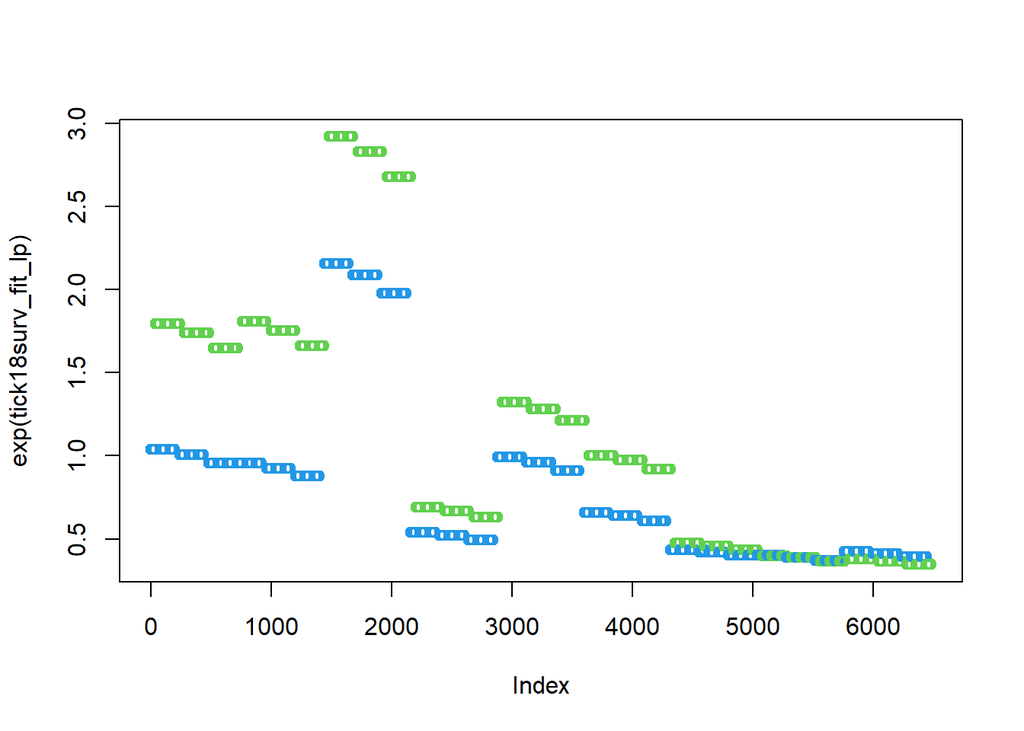

```r
## create predicted object and plot
## use predict, with correct object type (coxme model), will run predict.coxme()
tick18surv_fit_lp<- predict(tick18surv_model, type = "lp") # type can also = "risk", which looks like it's exponentiated lps (linear predictors)
tick18surv_fit_risk<- predict(tick18surv_model, type = "risk")


# checking that assumption
#lp plots
plot(exp(tick18surv_fit_lp), col = 3 + (tick18_final$species == "DEVA"))
```

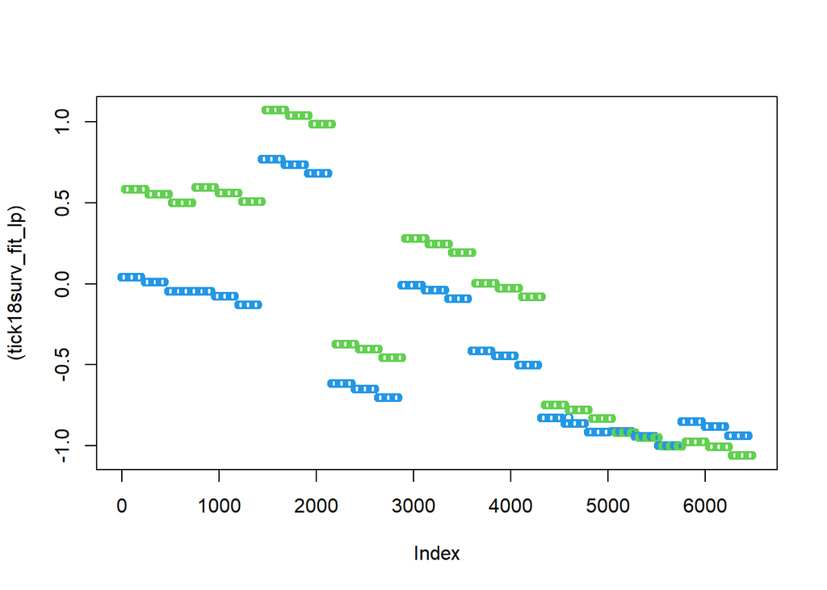

```r
plot((tick18surv_fit_lp), col = 3 + (tick18_final$species == "DEVA"))
```

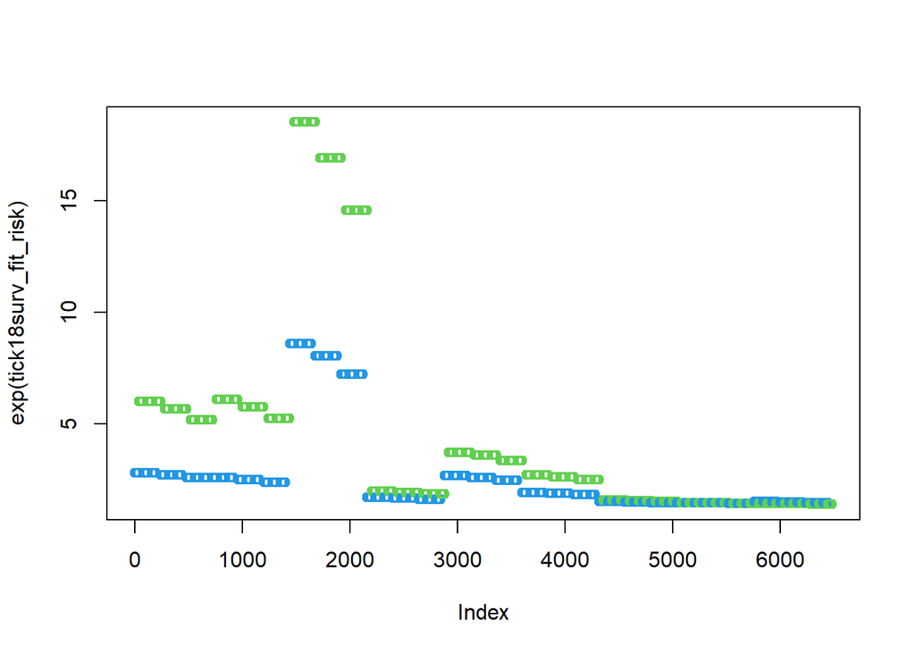

```r
# risk plots
plot(exp(tick18surv_fit_risk), col = 3 + (tick18_final$species == "DEVA"))
```

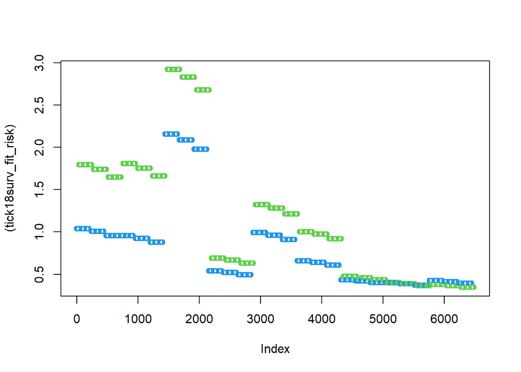

```r
plot((tick18surv_fit_risk), col = 3 + (tick18_final$species == "DEVA"))
```

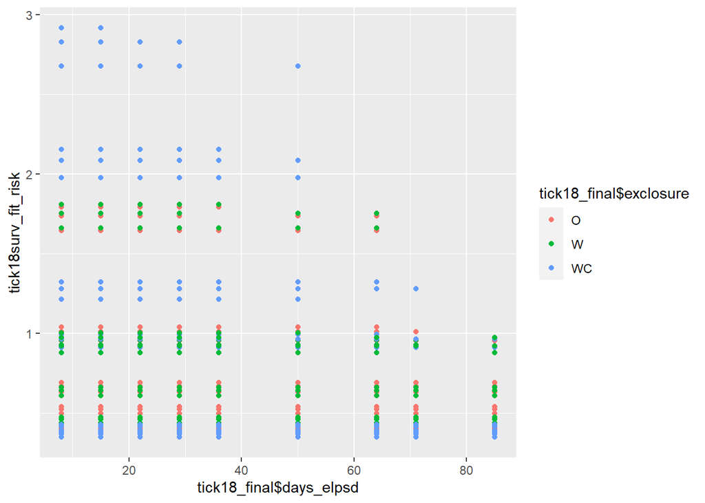

```r
# yep

# splitting by colors seems to only work when there are two levels to the variable, unsure why
# categorizing by just col = species, or whatever, isn't working
### Error in plot.xy(xy, type, ...) : invalid color name 'DEVA'

# what happens if we try to force time to be the x axis
## using qplot so I can actually split things up and color them:

# by exclosure
qplot(x = tick18_final$days_elpsd,
      y = tick18surv_fit_risk,
      color = tick18_final$exclosure)
```

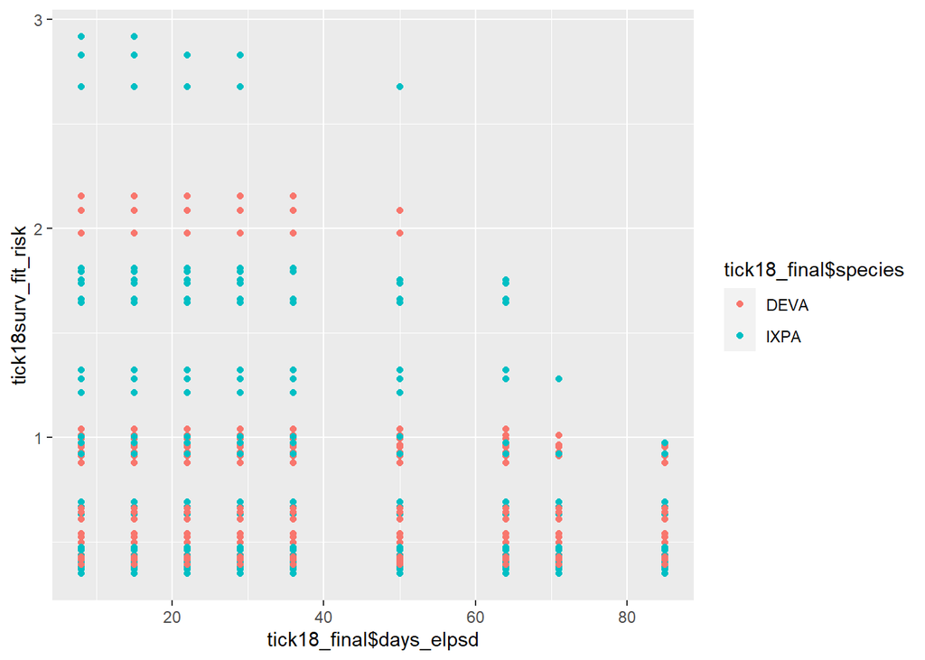

```r
# by species
qplot(x = tick18_final$days_elpsd,
      y = tick18surv_fit_risk,
      color = tick18_final$species)
```

### Running the model for the species separately

Dermacenter

```r
tick18_deva <- tick18_final %>%
  filter(species == "DEVA")
#create the survival object
deva18_surv<- (Surv(tick18_deva$days_elpsd, tick18_deva$death_t_f, type ="right"))

# create COX PH model with plot (exclosure) and site (climate) and the interaction, plus block as a random effect
deva18surv_model<-coxme(deva18_surv~ climate * exclosure + (1|block), data = tick18_deva)
deva18surv_model
```

```
## Cox mixed-effects model fit by maximum likelihood
##   Data: tick18_deva
##   events, n = 3093, 3239
##   Iterations= 5 33
##                     NULL Integrated    Fitted
## Log-likelihood -22361.38  -22013.53 -22010.79
##
##                    Chisq  df p    AIC    BIC
## Integrated loglik 695.71 9.0 0 677.71 623.38
##  Penalized loglik 701.18 9.7 0 681.79 623.26
##
## Model:  deva18_surv ~ climate * exclosure + (1 | block)
## Fixed coefficients
##                                  coef exp(coef)   se(coef)      z       p
## climateINTERM             -0.67327328 0.5100363 0.07587028  -8.87 0.0e+00
## climateMESIC              -0.97241529 0.3781685 0.07848807 -12.39 0.0e+00
## exclosureW                -0.08624943 0.9173654 0.07466093  -1.16 2.5e-01
## exclosureWC                0.75327305 2.1239404 0.07561907   9.96 0.0e+00
## climateINTERM:exclosureW   0.29699428 1.3458076 0.10657019   2.79 5.3e-03
## climateMESIC:exclosureW    0.17279862 1.1886267 0.10850949   1.59 1.1e-01
## climateINTERM:exclosureWC -0.12689024 0.8808303 0.10633138  -1.19 2.3e-01
## climateMESIC:exclosureWC  -0.69080505 0.5011724 0.10955757  -6.31 2.9e-10
##
## Random effects
##  Group Variable  Std Dev    Variance
##  block Intercept 0.07379695 0.00544599
```

```r
Anova(deva18surv_model)
```

```
## Analysis of Deviance Table (Type II tests)
##
## Response: deva18_surv
##                   Df   Chisq Pr(>Chisq)
## climate            2 561.226  < 2.2e-16 ***
## exclosure          2 140.130  < 2.2e-16 ***
## climate:exclosure  4  75.429  1.617e-15 ***
## ---
## Signif. codes:  0 '***' 0.001 '**' 0.01 '*' 0.05 '.' 0.1 ' ' 1
```

```r
# model with ranked exclosure values instead of categorical
deva18surv_model1 <-coxme(deva18_surv~ climate * excl_ranked + (1|block), data = tick18_deva)
deva18surv_model1
```

```
## Cox mixed-effects model fit by maximum likelihood
##   Data: tick18_deva
##   events, n = 3093, 3239
##   Iterations= 5 28
##                     NULL Integrated    Fitted
## Log-likelihood -22361.38   -22041.5 -22038.78
##
##                    Chisq   df p    AIC    BIC
## Integrated loglik 639.76 6.00 0 627.76 591.54
##  Penalized loglik 645.21 6.69 0 631.82 591.42
##
## Model:  deva18_surv ~ climate * excl_ranked + (1 | block)
## Fixed coefficients
##                                  coef exp(coef)   se(coef)      z       p
## climateINTERM             -0.70956028 0.4918604 0.12031423  -5.90 3.7e-09
## climateMESIC              -1.79072646 0.1668389 0.12452795 -14.38 0.0e+00
## excl_ranked               -0.37139999 0.6897680 0.04117584  -9.02 0.0e+00
## climateINTERM:excl_ranked  0.06085013 1.0627396 0.05606953   1.09 2.8e-01
## climateMESIC:excl_ranked   0.34022503 1.4052638 0.05690623   5.98 2.2e-09
##
## Random effects
##  Group Variable  Std Dev     Variance
##  block Intercept 0.073443201 0.005393904
```

```r
Anova(deva18surv_model1)
```

```
## Analysis of Deviance Table (Type II tests)
##
## Response: deva18_surv
##                     Df   Chisq Pr(>Chisq)
## climate              2 541.736  < 2.2e-16 ***
## excl_ranked          1 103.203  < 2.2e-16 ***
## climate:excl_ranked  2  41.544  9.523e-10 ***
## ---
## Signif. codes:  0 '***' 0.001 '**' 0.01 '*' 0.05 '.' 0.1 ' ' 1
```

```r
# model without interaction term
deva18surv_model2<-coxme(deva18_surv~ climate + exclosure + (1|block), data = tick18_deva)
deva18surv_model2
```

```
## Cox mixed-effects model fit by maximum likelihood
##   Data: tick18_deva
##   events, n = 3093, 3239
##   Iterations= 5 28
##                     NULL Integrated    Fitted
## Log-likelihood -22361.38  -22051.81 -22049.12
##
##                    Chisq   df p    AIC    BIC
## Integrated loglik 619.14 5.00 0 609.14 578.96
##  Penalized loglik 624.52 5.68 0 613.15 578.84
##
## Model:  deva18_surv ~ climate + exclosure + (1 | block)
## Fixed coefficients
##                      coef exp(coef)   se(coef)      z    p
## climateINTERM -0.59513570 0.5514877 0.04405210 -13.51 0.00
## climateMESIC  -1.13097296 0.3227191 0.04807198 -23.53 0.00
## exclosureW     0.06218903 1.0641635 0.04414464   1.41 0.16
## exclosureWC    0.47187780 1.6030015 0.04485745  10.52 0.00
##
## Random effects
##  Group Variable  Std Dev     Variance
##  block Intercept 0.072141425 0.005204385
```

```r
Anova(deva18surv_model2)
```

```
## Analysis of Deviance Table (Type II tests)
##
## Response: deva18_surv
##           Df  Chisq Pr(>Chisq)
## climate    2 557.32  < 2.2e-16 ***
## exclosure  2 129.65  < 2.2e-16 ***
## ---
## Signif. codes:  0 '***' 0.001 '**' 0.01 '*' 0.05 '.' 0.1 ' ' 1
```

```r
# without random block effect
deva18surv_model3<-coxph(deva18_surv~ climate + exclosure, data = tick18_deva)
summary(deva18surv_model3)
```

```
## Call:
## coxph(formula = deva18_surv ~ climate + exclosure, data = tick18_deva)
##
##   n= 3239, number of events= 3093
##
##                   coef exp(coef) se(coef)       z Pr(>|z|)
## climateINTERM -0.58992   0.55437  0.04401 -13.405   <2e-16 ***
## climateMESIC  -1.12106   0.32593  0.04787 -23.417   <2e-16 ***
## exclosureW     0.06116   1.06307  0.04414   1.386    0.166
## exclosureWC    0.46931   1.59889  0.04484  10.466   <2e-16 ***
## ---
## Signif. codes:  0 '***' 0.001 '**' 0.01 '*' 0.05 '.' 0.1 ' ' 1
##
##               exp(coef) exp(-coef) lower .95 upper .95
## climateINTERM    0.5544     1.8038    0.5086    0.6043
## climateMESIC     0.3259     3.0681    0.2967    0.3580
## exclosureW       1.0631     0.9407    0.9750    1.1591
## exclosureWC      1.5989     0.6254    1.4644    1.7458
##
## Concordance= 0.65  (se = 0.006 )
## Likelihood ratio test= 612  on 4 df,   p=<2e-16
## Wald test            = 610.2  on 4 df,   p=<2e-16
## Score (logrank) test = 641  on 4 df,   p=<2e-16
```

```r
Anova(deva18surv_model3)
```

```
## Analysis of Deviance Table (Type II tests)
##           LR Chisq Df Pr(>Chisq)
## climate     549.30  2  < 2.2e-16 ***
## exclosure   122.66  2  < 2.2e-16 ***
## ---
## Signif. codes:  0 '***' 0.001 '**' 0.01 '*' 0.05 '.' 0.1 ' ' 1
```

```r
#testing assumption of proportional hazards
## not sure how this works in coxme package, will update
#cox.zph(deva18surv_model)


#AIC comparison
AIC(deva18surv_model, deva18surv_model1, deva18surv_model2, deva18surv_model3)
```

```
##                         df      AIC
## deva18surv_model  9.695704 44040.97
## deva18surv_model1 6.693487 44090.94
## deva18surv_model2 5.684167 44109.61
## deva18surv_model3 4.000000 44118.76
```

```r
# first model still has lowest AIC

# we can directly interpret the magnitude of the random effect by exponentiating the coefficients
deva18_randoms<- ranef(deva18surv_model)
exp(deva18_randoms[[1]]) # can also use deva18_randoms$block to get coefficients
```

```
##         1         2         3
## 1.0314642 1.0480744 0.9250255
```

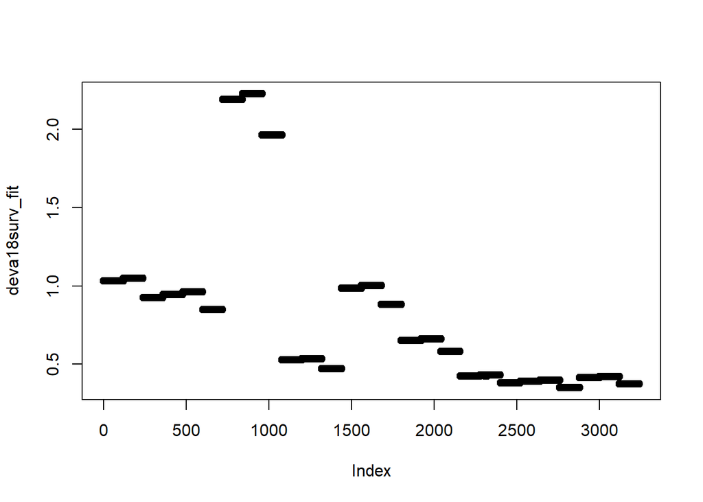

```r
# perdicting/plotting risk function
deva18surv_fit<- predict(deva18surv_model, type = "risk")
plot(deva18surv_fit)
```

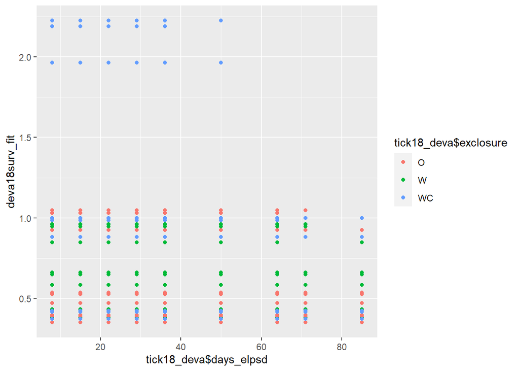

```r
# by time and exclosure
qplot(x = tick18_deva$days_elpsd,
      y = deva18surv_fit,
      color = tick18_deva$exclosure)
```

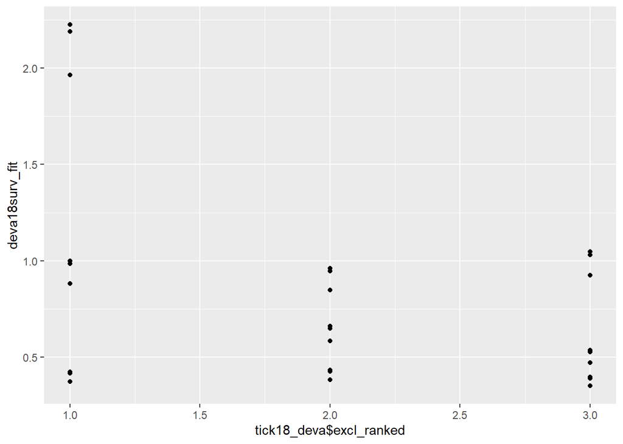

```r
# with ranked exlcosure (continuous variable) on x axis (even tho this model didn't perform well)
qplot(x = tick18_deva$excl_ranked,
      y = deva18surv_fit
      )
```

Ixodes

```r
tick18_ixpa <- tick18_final %>%
  filter(species == "IXPA")
#create the survival object
ixpa18_surv<- (Surv(tick18_ixpa$days_elpsd, tick18_ixpa$death_t_f, type ="right"))

# create COX PH model with plot (exclosure) and site (climate) and the interaction, plus block as a random effect
ixpa18surv_model<-coxme(ixpa18_surv~ climate * exclosure + (1|block), data = tick18_ixpa)
ixpa18surv_model
```

```
## Cox mixed-effects model fit by maximum likelihood
##   Data: tick18_ixpa
##   events, n = 3108, 3240
##   Iterations= 11 68
##                     NULL Integrated    Fitted
## Log-likelihood -22439.05  -21902.66 -21901.15
##
##                     Chisq   df p     AIC     BIC
## Integrated loglik 1072.79 9.00 0 1054.79 1000.41
##  Penalized loglik 1075.80 9.19 0 1057.42 1001.88
##
## Model:  ixpa18_surv ~ climate * exclosure + (1 | block)
## Fixed coefficients
##                                   coef exp(coef)   se(coef)      z       p
## climateINTERM             -0.929966984 0.3945667 0.07622696 -12.20 0.0e+00
## climateMESIC              -1.467370648 0.2305308 0.08018828 -18.30 0.0e+00
## exclosureW                 0.009304328 1.0093477 0.07453609   0.12 9.0e-01
## exclosureWC                0.465480295 1.5927790 0.07525784   6.19 6.2e-10
## climateINTERM:exclosureW   0.346496694 1.4141048 0.10614616   3.26 1.1e-03
## climateMESIC:exclosureW    0.158873181 1.1721893 0.10837105   1.47 1.4e-01
## climateINTERM:exclosureWC  0.160107944 1.1736376 0.10615833   1.51 1.3e-01
## climateMESIC:exclosureWC  -0.521183010 0.5938176 0.10977222  -4.75 2.1e-06
##
## Random effects
##  Group Variable  Std Dev     Variance
##  block Intercept 0.037910203 0.001437183
```

```r
Anova(ixpa18surv_model)
```

```
## Analysis of Deviance Table (Type II tests)
##
## Response: ixpa18_surv
##                   Df   Chisq Pr(>Chisq)
## climate            2 959.789  < 2.2e-16 ***
## exclosure          2  63.664  1.498e-14 ***
## climate:exclosure  4  60.912  1.866e-12 ***
## ---
## Signif. codes:  0 '***' 0.001 '**' 0.01 '*' 0.05 '.' 0.1 ' ' 1
```

```r
# model with ranked exclosure values instead of categorical
ixpa18surv_model1 <-coxme(ixpa18_surv~ climate * excl_ranked + (1|block), data = tick18_ixpa)
ixpa18surv_model1
```

```
## Cox mixed-effects model fit by maximum likelihood
##   Data: tick18_ixpa
##   events, n = 3108, 3240
##   Iterations= 9 47
##                     NULL Integrated    Fitted
## Log-likelihood -22439.05     -21913 -21911.55
##
##                     Chisq   df p     AIC     BIC
## Integrated loglik 1052.11 6.00 0 1040.11 1003.86
##  Penalized loglik 1055.01 6.16 0 1042.69 1005.48
##
## Model:  ixpa18_surv ~ climate * excl_ranked + (1 | block)
## Fixed coefficients
##                                 coef exp(coef)   se(coef)      z       p
## climateINTERM             -0.5929452 0.5526971 0.11632355  -5.10 3.4e-07
## climateMESIC              -2.0926150 0.1233641 0.12266914 -17.06 0.0e+00
## excl_ranked               -0.2310983 0.7936614 0.03911811  -5.91 3.5e-09
## climateINTERM:excl_ranked -0.0796563 0.9234337 0.05396816  -1.48 1.4e-01
## climateMESIC:excl_ranked   0.2576700 1.2939117 0.05504002   4.68 2.8e-06
##
## Random effects
##  Group Variable  Std Dev     Variance
##  block Intercept 0.036564836 0.001336987
```

```r
Anova(ixpa18surv_model1)
```

```
## Analysis of Deviance Table (Type II tests)
##
## Response: ixpa18_surv
##                     Df   Chisq Pr(>Chisq)
## climate              2 959.943  < 2.2e-16 ***
## excl_ranked          1  60.177  8.671e-15 ***
## climate:excl_ranked  2  42.037  7.442e-10 ***
## ---
## Signif. codes:  0 '***' 0.001 '**' 0.01 '*' 0.05 '.' 0.1 ' ' 1
```

```r
# model without interaction term
ixpa18surv_model2<-coxme(ixpa18_surv~ climate + exclosure + (1|block), data = tick18_ixpa)
ixpa18surv_model2
```

```
## Cox mixed-effects model fit by maximum likelihood
##   Data: tick18_ixpa
##   events, n = 3108, 3240
##   Iterations= 10 52
##                     NULL Integrated    Fitted
## Log-likelihood -22439.05  -21933.96 -21932.73
##
##                     Chisq   df p     AIC    BIC
## Integrated loglik 1010.19 5.00 0 1000.19 969.98
##  Penalized loglik 1012.66 5.03 0 1002.61 972.24
##
## Model:  ixpa18_surv ~ climate + exclosure + (1 | block)
## Fixed coefficients
##                     coef exp(coef)   se(coef)      z       p
## climateINTERM -0.7496576 0.4725283 0.04441301 -16.88 0.0e+00
## climateMESIC  -1.5699796 0.2080494 0.05054045 -31.06 0.0e+00
## exclosureW     0.1747144 1.1909060 0.04412604   3.96 7.5e-05
## exclosureWC    0.3466117 1.4142675 0.04479704   7.74 1.0e-14
##
## Random effects
##  Group Variable  Std Dev     Variance
##  block Intercept 0.031925955 0.001019267
```

```r
Anova(ixpa18surv_model2)
```

```
## Analysis of Deviance Table (Type II tests)
##
## Response: ixpa18_surv
##           Df   Chisq Pr(>Chisq)
## climate    2 966.161  < 2.2e-16 ***
## exclosure  2  59.875  9.961e-14 ***
## ---
## Signif. codes:  0 '***' 0.001 '**' 0.01 '*' 0.05 '.' 0.1 ' ' 1
```

```r
# without random block effect
ixpa18surv_model3<-coxph(ixpa18_surv~ climate + exclosure, data = tick18_ixpa)
summary(ixpa18surv_model3)
```

```
## Call:
## coxph(formula = ixpa18_surv ~ climate + exclosure, data = tick18_ixpa)
##
##   n= 3240, number of events= 3108
##
##                   coef exp(coef) se(coef)       z Pr(>|z|)
## climateINTERM -0.74966   0.47253  0.04440 -16.886  < 2e-16 ***
## climateMESIC  -1.56892   0.20827  0.05052 -31.058  < 2e-16 ***
## exclosureW     0.17378   1.18979  0.04412   3.939 8.19e-05 ***
## exclosureWC    0.34712   1.41498  0.04479   7.750 9.18e-15 ***
## ---
## Signif. codes:  0 '***' 0.001 '**' 0.01 '*' 0.05 '.' 0.1 ' ' 1
##
##               exp(coef) exp(-coef) lower .95 upper .95
## climateINTERM    0.4725     2.1163    0.4332    0.5155
## climateMESIC     0.2083     4.8015    0.1886    0.2299
## exclosureW       1.1898     0.8405    1.0912    1.2972
## exclosureWC      1.4150     0.7067    1.2961    1.5448
##
## Concordance= 0.708  (se = 0.006 )
## Likelihood ratio test= 1010  on 4 df,   p=<2e-16
## Wald test            = 983.6  on 4 df,   p=<2e-16
## Score (logrank) test = 1084  on 4 df,   p=<2e-16
```

```r
Anova(ixpa18surv_model3)
```

```
## Analysis of Deviance Table (Type II tests)
##           LR Chisq Df Pr(>Chisq)
## climate     989.23  2  < 2.2e-16 ***
## exclosure    59.99  2  9.401e-14 ***
## ---
## Signif. codes:  0 '***' 0.001 '**' 0.01 '*' 0.05 '.' 0.1 ' ' 1
```

```r
#testing assumption of proportional hazards
## not sure how this works in coxme package, will update
#cox.zph(ixpa18surv_model)


#AIC comparison
AIC(ixpa18surv_model, ixpa18surv_model1, ixpa18surv_model2, ixpa18surv_model3)
```

```
##                         df      AIC
## ixpa18surv_model  9.193111 43820.69
## ixpa18surv_model1 6.159541 43835.42
## ixpa18surv_model2 5.025675 43875.50
## ixpa18surv_model3 4.000000 43876.57
```

```r
# first model still has lowest AIC

# we can directly interpret the magnitude of the random effect by exponentiating the coefficients
ixpa18_randoms<- ranef(ixpa18surv_model)
exp(ixpa18_randoms[[1]])
```

```
##         1         2         3
## 1.0342647 0.9804035 0.9861965
```

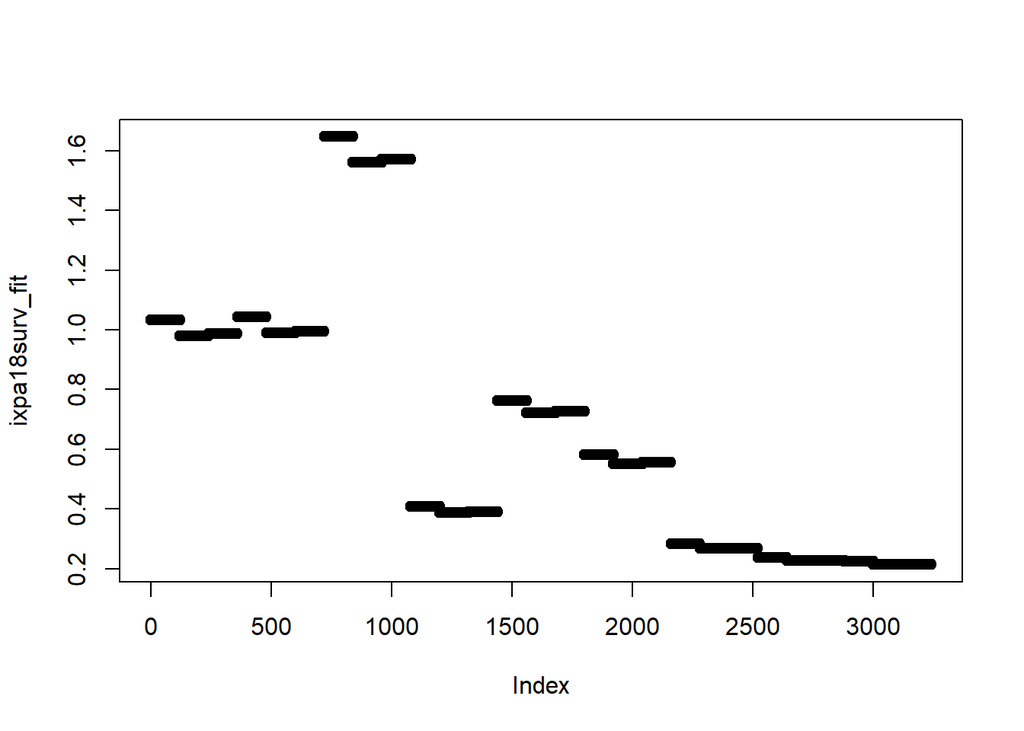

```r
# perdicting/plotting risk function
ixpa18surv_fit<- predict(ixpa18surv_model, type = "risk")
plot(ixpa18surv_fit)
```

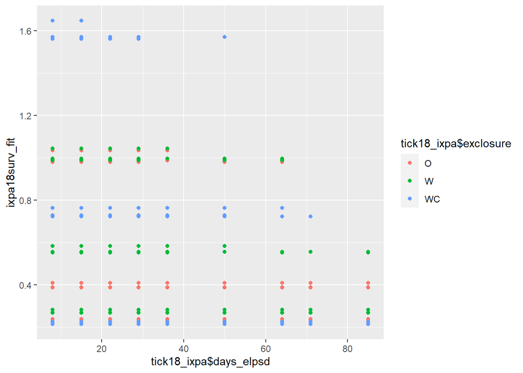

```r
# by time and exclosure
qplot(x = tick18_ixpa$days_elpsd,
      y = ixpa18surv_fit,
      color = tick18_ixpa$exclosure)
```

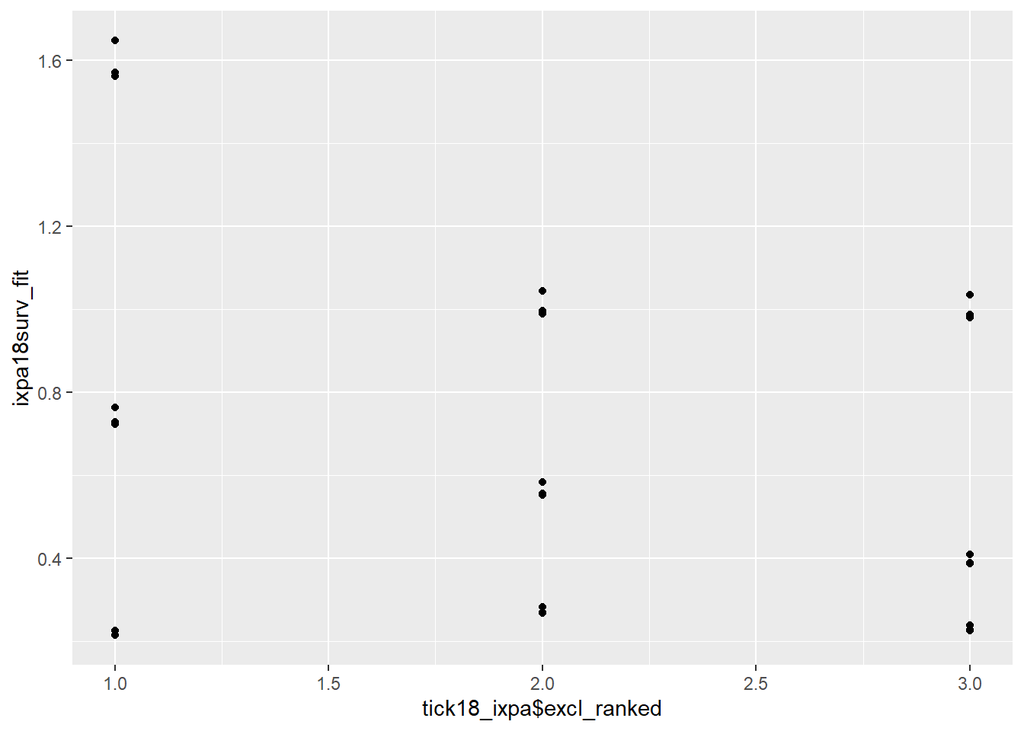

```r
# with ranked exlcosure (continuous variable) on x axis (even tho this model didn't perform well)
qplot(x = tick18_ixpa$excl_ranked,
      y = ixpa18surv_fit
      )
```

##Adding Analyses for Microclimate ~ Survival

Note from Dev: so a couple things: for temperature, there are fewer mesic dates than interim and arid, so might want to just use the dates that correspond to the tick cage checks. And humidity needs to be tidied still.

### Cleaning and Exploring Climate Data

*to do:* - melt this so there is an entry per plot per date - attach to temperature data - average - ANOVA between plots - plot raw data to check out dist - plot raw data vs date

Cleaning Humidity

```r
# pull in humidity CSV
humidity<-read_csv("humidity2018.csv")
```

```r
#head(humidity)


# pivot longer is going to make things vertical, so each date of checking + plot has its own row

humid_clean <- humidity %>%
  pivot_longer(names_to = "plotID", values_to = "humidity", cols = c("AR_1_Open_1" :"ME_3_T_3")) %>%
  #arrange(plotID) %>%   # sorts by plot ID, only necessary when i was figuring stuff out
  concat.split( 3, sep = "_", drop = TRUE) %>%   #need to split concatenated plotID into its parts (which are climate_block#_treatment_cage#) ... I guess 'separate()' is the tidyverse version?
  rename(Climate_Level = plotID_1, Block = plotID_2, Treatment = plotID_3, cage = plotID_4) %>%
  dplyr::group_by(Climate_Level, Block, Treatment, Date) %>%
  summarize(mean_humid = mean(humidity)) %>%    #average the humidity at the plot level to match temp
  mutate(Treatment = case_when(Treatment == "Open"~ "O",
                               Treatment == "T" ~ "T",
                               Treatment == "P" ~"P"))%>%  # replaces treatment names with letters to match temp, this way is fucking stupid but "replace" throws an error I can't figure out
#in baseR is easy: humid_clean$Treatment[humid_clean$Treatment == "Open"] <- "O"
# could have also used forcats::fct_recode because Treatment became a factor somehow

  unite("plotID", c(Climate_Level,Treatment, Block), sep= "") #now we need to re-concatenate the plotID so it matches temperature
head(humid_clean)
```

```
## # A tibble: 6 x 3
##   plotID Date       mean_humid
##   <chr>  <chr>           <dbl>
## 1 ARO1   10/21/2018       12.7
## 2 ARO1   10/7/2018        10.9
## 3 ARO1   7/29/2018        22.4
## 4 ARO1   8/12/2018        18.8
## 5 ARO1   8/19/2018        16.3
## 6 ARO1   8/26/2018        15.3
```

```r
str(humid_clean)
```

```
## tibble [297 x 3] (S3: tbl_df/tbl/data.frame)
##  $ plotID    : chr [1:297] "ARO1" "ARO1" "ARO1" "ARO1" ...
##  $ Date      : chr [1:297] "10/21/2018" "10/7/2018" "7/29/2018" "8/12/2018" ...
##  $ mean_humid: num [1:297] 12.7 10.9 22.4 18.8 16.3 ...
```

```r
#write_csv(humid_long, "humidity_clean.csv")
```

Humidity data frame should somewhat match temperature data frame now, but there are more temperature dates than humidity ones. So we will need to combine the two with this in mind!

```r
# import temperature data
temp <- read_csv("temp2018.csv") %>%
  select(Date, Plot_ID, Temp) %>%
  rename(plotID = Plot_ID)
# now smash them together using base R i guess...

microclimate <- merge(temp, humid_clean) %>%
  arrange(plotID, Date)

microclimate$Date <- mdy(microclimate$Date) # necessary to get dates recognized

head(microclimate)
```

```
##         Date plotID     Temp mean_humid
## 1 2018-10-21   ARO1 29.73120   12.68000
## 2 2018-10-07   ARO1 39.98840   10.89000
## 3 2018-07-29   ARO1 44.24973   22.40667
## 4 2018-08-12   ARO1 44.16153   18.83667
## 5 2018-08-19   ARO1 45.81813   16.32667
## 6 2018-08-26   ARO1 42.95866   15.30667
```

Visualize and play around with the climate data before we bind to the tick data:

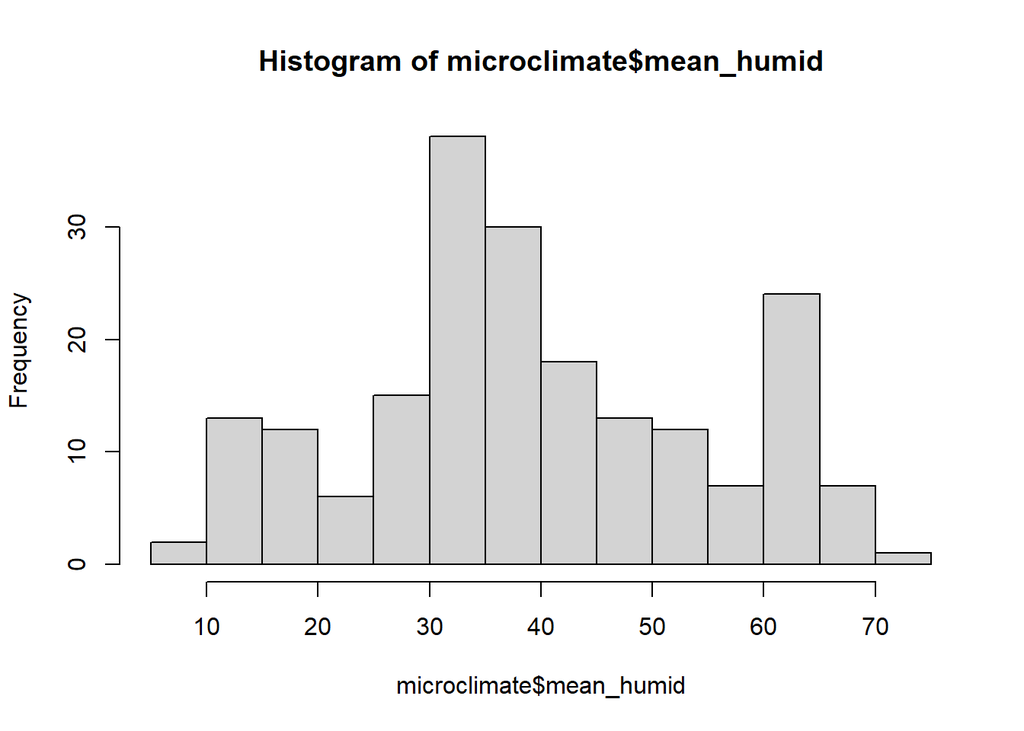

```r
attach(microclimate)
# look at distributions
# humidity
hist(microclimate$mean_humid)
```

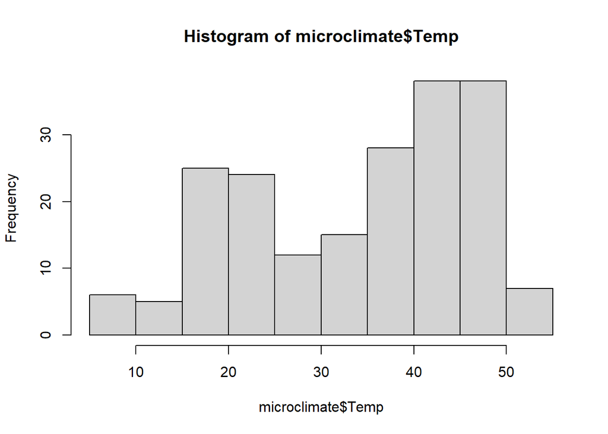

```r
# looks somewhat normal except for all the 65 degree days

# humidity
hist(microclimate$Temp)
```

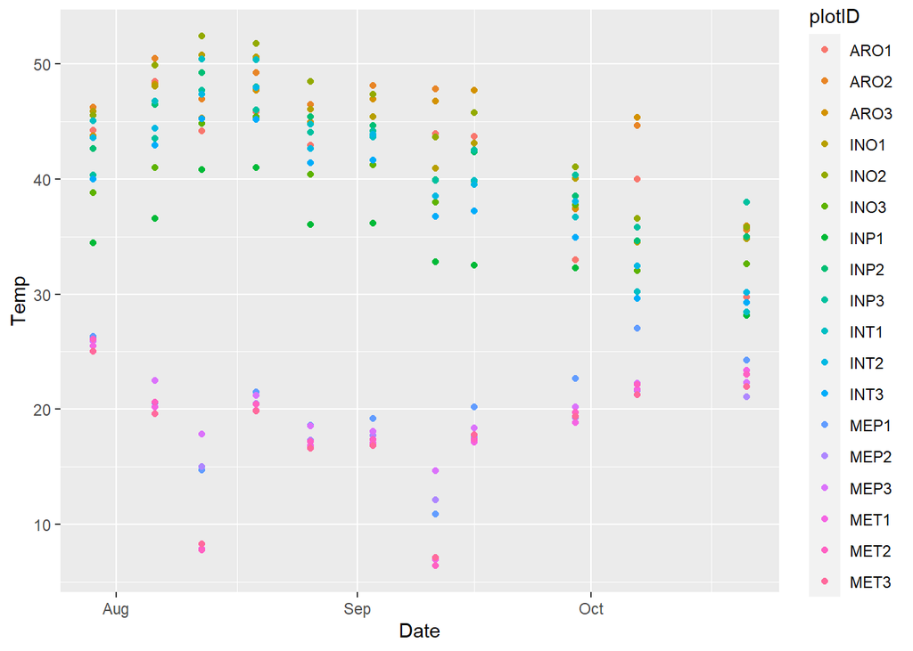

```r
# definitely not normal

# are either related to time though?
qplot(Date,Temp, colour = plotID)
```

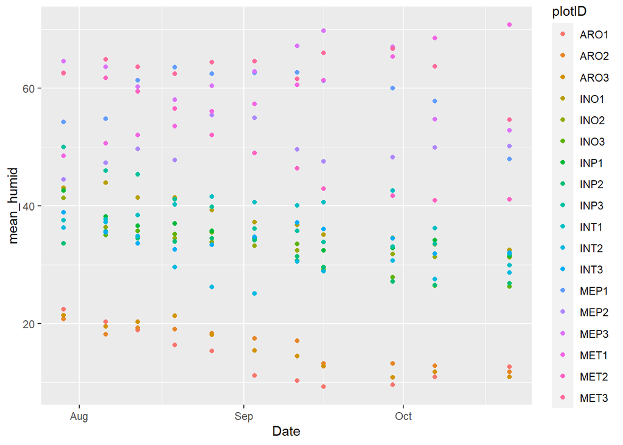

```r
qplot(Date, mean_humid, colour = plotID)
```

## 2019

### Data Wrangling (2019)

```r
#2019
tick19<- read_csv("tick2019.csv")
```

```r
# dataset is tick19

#View(tick19)

# data is already tidy

# want to rename "plot" to "exclosure" and "site" to "climate" though, for confusion's sake
tick19clean <- tick19 %>%
  select(site, block, plot, Location_ID, days_elpsd, death_tf) %>%
  rename(climate = site, exclosure = plot, microclimate = Location_ID) %>%
  mutate(excl_ranked = case_when(
    exclosure == "Total" ~ 3,
    exclosure == "Partial" ~ 2,
    exclosure == "Control" ~ 1
  ))

head(tick19clean)
```

```
## # A tibble: 6 x 7
##   climate      block exclosure microclimate days_elpsd death_tf excl_ranked
##   <chr>        <dbl> <chr>     <chr>             <dbl>    <dbl>       <dbl>
## 1 Intermediate     1 Control   under_oak            14        1           1
## 2 Intermediate     1 Control   under_oak            14        1           1
## 3 Intermediate     1 Control   under_oak            35        1           1
## 4 Intermediate     1 Control   under_oak            35        1           1
## 5 Intermediate     1 Control   open                 14        1           1
## 6 Intermediate     1 Control   open                 14        1           1
```